Skip to contents

# Building a 188 x 282 pooling matrix

Muhammad Yaseen

2026-10-01

Source: [`vignettes/ppgt_pp_188x282.qmd`](https://github.com/myaseen208/ppgt/blob/HEAD/vignettes/ppgt_pp_188x282.qmd)

## 1 Purpose

This vignette works through a single concrete Polynomial Pools (PP) design: **282 specimens tested using 188 pools**, where every specimen is placed in exactly 4 pools and every pool holds exactly 6 specimens. That is a design with

- $N = 282$ specimens (columns of $\mathbf{M}$),
- $J = 188$ pools (rows of $\mathbf{M}$),
- pool size $n_j = 6$ for every pool $j$,
- column weight $w_i = 4$ for every specimen $i$.

## 2 Installation

`ppgt` is not yet on CRAN. Install the development version from GitHub:

```r
# install.packages("pak")
pak::pak("myaseen208/ppgt")

# or with remotes
# install.packages("remotes")
remotes::install_github("myaseen208/ppgt")
```

## 3 Construction

The matrix is built with a single call to `pp_matrix()`:

```r
M4 <- pp_matrix(q = 47, d = 3, nl = 4, N = 282)
dim(M4)
  [1] 188 282
```

`pp_matrix()` builds its design over the finite field $\mathrm{GF}(q)$, using dimension `d` and `nl` layers (see `?pp_matrix` and the `ppgt_pp` vignette for the full construction). The three arguments interact as follows:

- `q = 47` is the field order. 47 is prime, so $\mathrm{GF}(47)$ exists, and each layer of the design contributes exactly $q = 47$ pools.
- `nl = 4` is the number of layers, so the pool count is $J = n_l \, q = 4 \times 47 = 188$, and every specimen is assigned to exactly $n_l = 4$ pools (one per layer).
- `d = 3` is the PP dimension, which fixes the canonical pool size to $q^{d-1} = 47^2 = 2209$ in the *full* (untruncated) design with $N_{\max} = q^d = 47^3$ specimens.
- `N = 282` truncates that full design down to its first 282 columns. Because $282 = 6 \times 47 = 6q$ is a small multiple of $q$, the truncated design keeps only 6 of the $q^{d-2} = 47$ possible “column blocks” per pool, so every pool’s row sum drops from the full-design value of 2209 down to 6.

The two products $188 = 4 \times 47$ and $282 = 6 \times 47$ both factor through $q = 47$, and this is exactly what keeps every row sum equal to 6 and every column weight equal to 4 (rather than only approximately so): $q$ divides $N$ exactly (`pp_matrix()` requires `N %% q == 0`), so the truncation boundary falls cleanly between pool blocks and does not cut any pool’s row in half.

Every incidence $M_{ji} = 1$ is counted once from the pool side (as a 1 in row $j$) and once from the specimen side (as a 1 in column $i$), so the total number of incidences can be computed two ways:
$$J \, n_j = 188 \times 6 = 1128, \qquad N \, w_i = 282 \times 4 = 1128.$$
Both give the same total, 1128, which is confirmed numerically below.

## 4 Verification

```r
dim(M4)
  [1] 188 282

# apply() works directly on the sparse matrix, matching the original script
table(apply(M4, 1, sum))

    6
  188
table(apply(M4, 2, sum))

    4
  282

# rowSums()/colSums() dispatch to Matrix's sparse-aware methods (library(Matrix)
# was attached above) and are much faster for larger matrices
table(rowSums(M4))

    6
  188
table(colSums(M4))

    4
  282

stopifnot(
  nrow(M4) == 188L,
  ncol(M4) == 282L,
  all(Matrix::rowSums(M4) == 6L),
  all(Matrix::colSums(M4) == 4L)
)

total_incidences <- sum(M4)
total_incidences
  [1] 1128
stopifnot(total_incidences == 188L * 6L, total_incidences == 282L * 4L)
```

### 4.1 Pairwise overlap between specimens

The PP construction guarantees that any two distinct specimens share at most $d - 1$ pools. With $d = 3$ here, that bound is 2. The specimen-by-specimen overlap matrix is $\mathbf{M}^\top\mathbf{M}$; its off-diagonal entries are the pairwise pool-sharing counts $|\mathcal{J}_i \cap \mathcal{J}_{i'}|$:

```r
overlap <- Matrix::crossprod(M4)
diag(overlap) <- 0L  # ignore the diagonal (each specimen "overlaps" itself)

max_overlap <- max(overlap)
max_overlap
  [1] 1

stopifnot(max_overlap <= 2L)  # the d - 1 = 2 theoretical bound
```

The maximum pairwise overlap actually attained, 1, is within the theoretical bound $d - 1 = 2$.

## 5 Efficiency

Testing all 282 specimens individually would need 282 tests. This design needs only $J = 188$ pooled tests, a saving of

```r
n_specimens <- ncol(M4)
n_pools <- nrow(M4)

n_specimens
  [1] 282
n_pools
  [1] 188

saving_pct <- 100 * (1 - n_pools / n_specimens)
round(saving_pct, 1)
  [1] 33.3
```

so pooling 282 specimens into 188 pools cuts the number of tests by about 33.3%, at the cost of the resolution limits discussed next.

## 6 Decoding

`pp_decode()` runs the package’s combined-oracle stage-1 pipeline (COMP, then GPSR refinement if needed) on observed pool outcomes; see `?pp_decode` and the `ppgt_pp` vignette for the full pipeline. This matrix’s stored detection limit is:

```r
attr(M4, "pp")$k_max
  [1] 1
```

so exact COMP recovery is guaranteed only up to 1 true positive out of 282. The example below simulates exactly that many positives with a fixed seed, so the whole example is reproducible.

```r
set.seed(20260926)

Y_tilde <- integer(n_specimens)
Y_tilde[137] <- 1L  # the one simulated positive specimen

# Latent pool status: z_tilde_j = 1 iff pool j contains at least one positive
z_tilde <- as.integer(as.vector(M4 %*% Y_tilde) > 0L)
sum(z_tilde)  # number of positive pools
  [1] 4

decoded <- pp_decode(M4, z_tilde, verbose = FALSE)
decoded$positives
  [1] 137
decoded$method
  [1] "COMP (exact)"

stopifnot(identical(decoded$positives, which(Y_tilde == 1L)))
```

`pp_decode()` recovers the single simulated positive specimen exactly, using only the 4 positive pools out of 188 as evidence.

## 7 Matrix structure

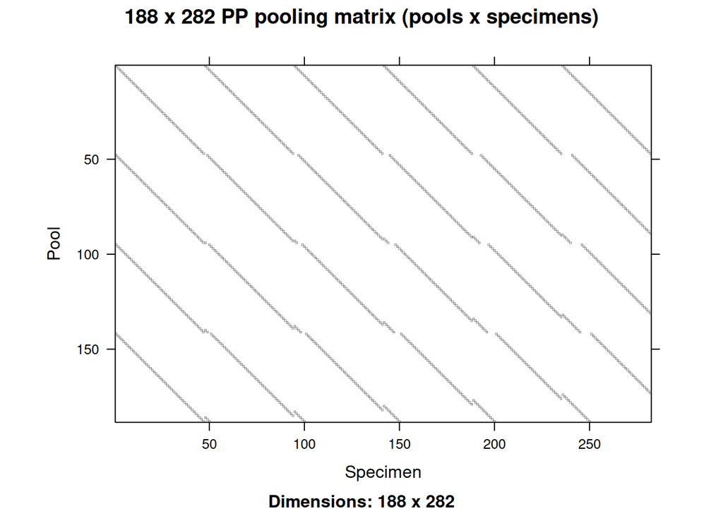

```r
Matrix::image(
  M4,
  main = "188 x 282 PP pooling matrix (pools x specimens)",
  xlab = "Specimen",
  ylab = "Pool"
)
```

Each layer of `nl = 4` contributes a horizontal band of $q = 47$ pools; the banded pattern reflects the polynomial-evaluation structure described in the `ppgt_pp` vignette.

## 8 Session info

```r
sessionInfo()
  R version 4.6.1 (2026-06-24)
  Platform: x86_64-pc-linux-gnu
  Running under: Ubuntu 26.04.1 LTS

  Matrix products: default
  BLAS:   /usr/lib/x86_64-linux-gnu/openblas-pthread/libblas.so.3
  LAPACK: /usr/lib/x86_64-linux-gnu/openblas-pthread/libopenblasp-r0.3.32.so;  LAPACK version 3.12.0

  locale:
   [1] LC_CTYPE=en_US.UTF-8       LC_NUMERIC=C
   [3] LC_TIME=en_US.UTF-8        LC_COLLATE=en_US.UTF-8
   [5] LC_MONETARY=en_US.UTF-8    LC_MESSAGES=en_US.UTF-8
   [7] LC_PAPER=en_US.UTF-8       LC_NAME=C
   [9] LC_ADDRESS=C               LC_TELEPHONE=C
  [11] LC_MEASUREMENT=en_US.UTF-8 LC_IDENTIFICATION=C

  time zone: America/New_York
  tzcode source: system (glibc)

  attached base packages:
  [1] stats     graphics  grDevices utils     datasets  methods   base

  other attached packages:
  [1] Matrix_1.7-6 ppgt_0.1.2

  loaded via a namespace (and not attached):
   [1] digest_0.6.39   fastmap_1.2.0   xfun_0.61       lattice_0.23-1
   [5] knitr_1.52      htmltools_0.5.9 rmarkdown_2.32  cli_3.6.6
   [9] grid_4.6.1      compiler_4.6.1  tools_4.6.1     evaluate_1.0.5
  [13] yaml_2.3.12     otel_0.2.0      rlang_1.3.0     jsonlite_2.0.0
```